# Assessing inputs and outcomes in the lending process at Prosper

## by Henry Owens

## Investigation Overview

This investigation assesses the relationships between inputs to the lending process (i.e., credit score, Prosper's proprietary rating, and borrower characteristics like income and reason for borrowing), and outcomes in the process (i.e., interest rate/APR, loan default or repayment outcome, loan amount and term).

## Dataset Overview

I started out with data covering 81 columns of variables for over 100,000 loans made by Prosper from November 2005 to March 2014. The majority are loans made to individuals for debt consolodation. Most of the loans are 15000 dollars or less.

Some of the columns I was interested in (Prosper Rating, debt to income) were not populated in all rows, so after omitting those columns I was left with about 77,000 rows each on a unique loan.

## Distribution of loan category:

### Why do people borrow from Prosper?

This humble chart shows that the vast majority of people borrow from Prosper to consolidate existing debt.

This is important to know off the bat as context for understanding the business model of the lender and the situation of the borrowers.

Prosper's bread and butter is helping people payoff old debt with new debt.

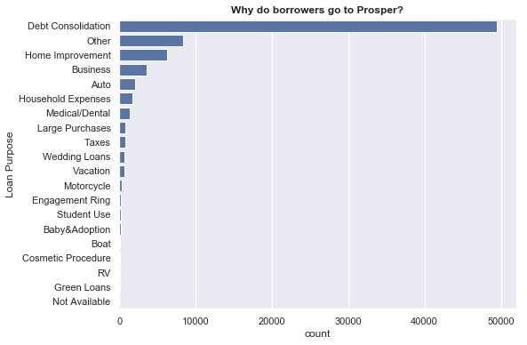

```python
sb.set(style="darkgrid")
plt.figure(figsize=[8,6])
base_color = sb.color_palette()[0]
cat_order = dfloan['loancategory'].value_counts().index
sb.countplot(data = dfloan, y = 'loancategory', color = base_color, order=cat_order)
plt.ylabel('Loan Purpose')
plt.title('Why do borrowers go to Prosper?', weight='bold') ;
```

## Loan Characteristics:

Aside from the overwhelming spike at the mode of 36%, the distribution of APR is centered on 20% with moderate right skew.

I got curious about why 36% is so common, and discovered that is the highest APR you can charge for consumer loans in 15 states.

```
See: "Why 36%? The History, Use, and Purpose of the 36% Interest Rate Cap," Lauren K. Saunders, National Consumer Law Center.
```

https://www.nclc.org/images/pdf/pr-reports/why36pct.pdf

The most common loan amount for Prosper borrowers is 4000 dollars (pretty small!). Loan amounts tend to cluster around even numbers: 4000, 10000, 15000, 20000, and so on.

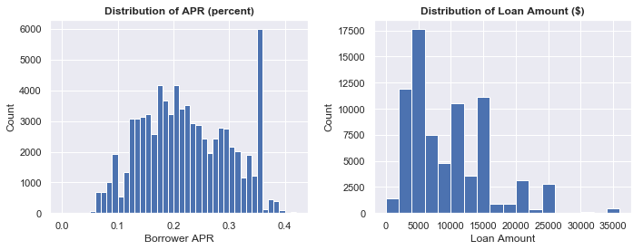

```python
plt.figure(figsize = [10,4]) # larger figure size for subplots


plt.subplot(1, 2, 1) # 1 row, 2 cols, subplot 1
bins = np.arange(0, dfloan.apr.max()+0.005, 0.01)
plt.hist(data = dfloan, x = 'apr', bins = bins);
plt.title('Distribution of APR (percent)', weight='bold')
plt.xlabel('Borrower APR')
plt.ylabel('Count')

plt.subplot(1, 2, 2)
bins = np.arange(0, dfloan.loanamount.max()+2000, 2000)
#plt.figure(figsize=[8, 6])
plt.hist(data = dfloan, x = 'loanamount', bins=bins);
plt.title('Distribution of Loan Amount ($)', weight='bold')
plt.xlabel('Loan Amount')
plt.ylabel('Count')
plt.tight_layout();
```

## Bad Loans: Prosper Rating and Credit Score

### Does Prosper have a "secret sauce" in their Ratings?

This chart shows the distributions of prosper rating and credit score for the 'bad' loan categories as a percent of 'bad' loans. This allows for some comparison, even though the ratings/scores are different types of data.

It shows that the Prosper Rating and Credit Score have similar relationships with 'bad' loan outcomes.

It's not obvious that Prosper is doing a signifincantly better job at credit assessment with its rating than the credit bureaus, since over 10 percent of all bad loans that were charged off had 'AA', 'A,' or 'B' ratings. If the Prosper Ratings had more left skew then you could conclude that they were doing better, but it is hard to say if one is better based on this comparison.

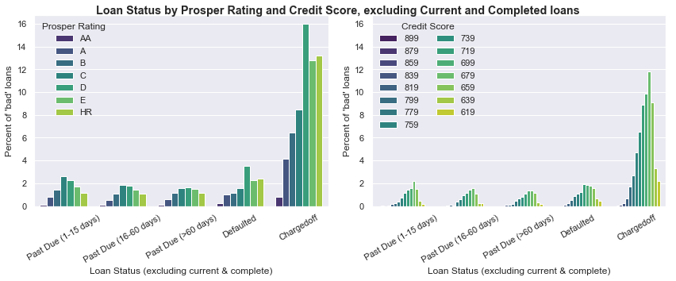

```python
# The distribution of the PERCENT of loans in a certain status,
# broken down by prosper score and rating. I use income as the y variable because
# it needs a numerical variable.

fig = plt.figure(figsize=[12,5])

ax1 = plt.subplot(1,2,1)
ax1 = sb.barplot(x="loanstatus", y="income", data=dfloan_notgood, order=status_order,
                estimator=lambda x: len(x) / len(dfloan_notgood) * 100, hue='prosperrating',
                palette='viridis')
ax1.set(ylabel="Percent of 'bad' loans", xlabel='Loan Status (excluding current & complete)')
plt.xticks(rotation=30)
ax1.legend(title='Prosper Rating', frameon=False,)

score_order = dfloan.creditscore.value_counts().index.sort_values(ascending=False)

ax2 = plt.subplot(1,2,2, sharey=ax1)
ax2 = sb.barplot(x="loanstatus", y="income", data=dfloan_notgood, order=status_order,
                estimator=lambda x: len(x) / len(dfloan_notgood) * 100, hue='creditscore',
               palette='viridis', hue_order=score_order)
ax2.set(ylabel="Percent of 'bad' loans", xlabel='Loan Status (excluding current & complete)')
plt.xticks(rotation=30)

ax2.legend(title='Credit Score', frameon=False, ncol=2)

fig.suptitle('Loan Status by Prosper Rating and Credit Score, excluding Current and Completed loans',
             fontweight='bold')
plt.tight_layout();
```

## Prosper Rating: APR and DTI

This pair of charts compares Prosper Rating with (1) APR and (2) Debt to Income.

### How does APR fit with Prosper Rating? Like a glove!!

Relationship between APR and Prosper Rating shows clearly that riskier borrowers as measured by Prosper pay higher rates.

### How big of a deal is Debt to Income in the Prosper Rating? Meh...

Prosper Rating and Debt to Income shows a more subtle relationship than I expected. It is there, but there must be many more factors in the rating process.

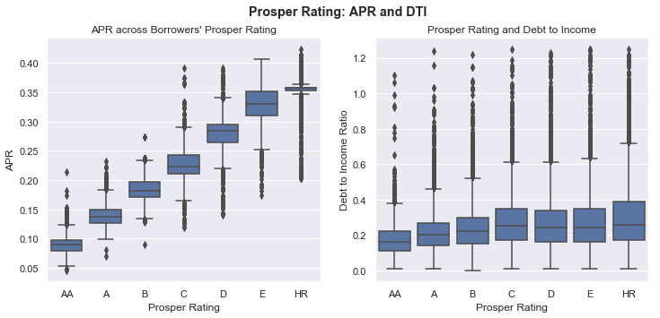

```python
fig = plt.figure(figsize=[12,5])

plt.subplot(1,2,1)
base_color = sb.color_palette()[0]
sb.boxplot(data = dfloan, x = 'prosperrating', y = 'apr', order=rating_order,
           color=base_color)
plt.title('APR across Borrowers\' Prosper Rating')
plt.xlabel('Prosper Rating')
plt.ylabel('APR')

plt.subplot(1,2,2)
base_color = sb.color_palette()[0]
sb.boxplot(data = dfloan, x = 'prosperrating', y = 'debttoincome',
           order=rating_order, color=base_color)
plt.title('Prosper Rating and Debt to Income')
plt.xlabel('Prosper Rating')
plt.ylabel('Debt to Income Ratio')

fig.suptitle('Prosper Rating: APR and DTI', fontweight='bold');
```

## Another look at Debt to Income, APR and Prosper Ratings

### How important is DTI in Prosper Rating and APR?

Digging a little deeper, here we can tease out a pattern of increasing DTI for the higher risk borrowers.

Low DTI will not prevent the lender from charging a high rate, but it does seem like a prerequisite for a good Prosper Rating: most of the 'AA' borrowers have DTI below 0.25. But then again so do many of the other borrowers.

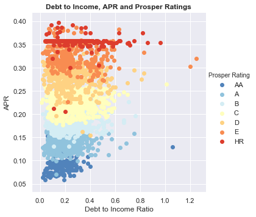

```python
# Plotting rating, DTI and APR. Using sample to speed it up and lighten the chart
dfsample = dfloan.sample(2500);

g = sb.FacetGrid(data = dfsample, hue = 'prosperrating', hue_order=rating_order,
                 size=5, palette='RdYlBu_r')
g.map(plt.scatter, 'debttoincome', 'apr', alpha=1)
g.add_legend(title='Prosper Rating')
plt.title('Debt to Income, APR and Prosper Ratings', fontweight="bold")
plt.xlabel('Debt to Income Ratio')
plt.ylabel('APR');
```

## Interactions of Prosper Rating, Loan Status and Numerical Variables

### Can we tease out any hidden relationships among subgroups?

These plots show mostly tight relationships among the loan status subgroups of the prosper rating levels across different numerical variables.

The exception might be the 'AA' loans, but the small sample size makes it hard to say.

```python
status_order2 = ['Current', 'Completed', 'Past Due (1-15 days)', 'Past Due (16-60 days)',
                'Past Due (>60 days)', 'Defaulted', 'Chargedoff']
```

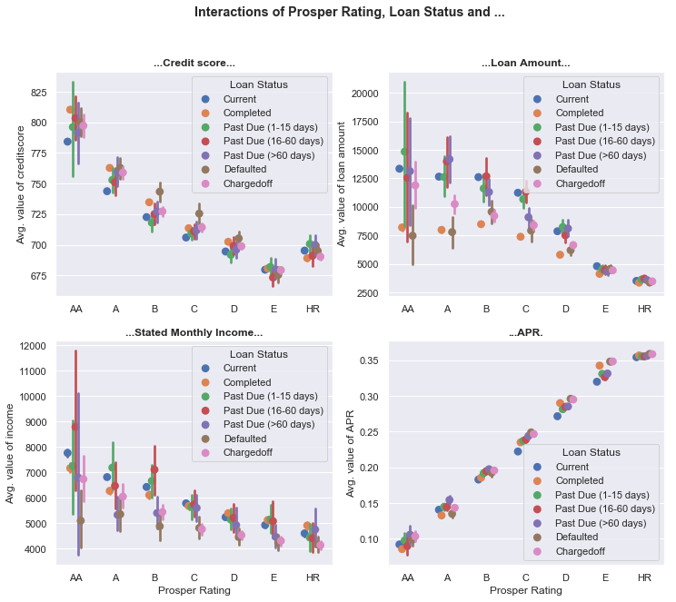

```python
# plotting Prosper rating, loan status, and cat vars.

fig = plt.figure(figsize=[12,10])

plt.subplot(2,2,1)
sb.pointplot(data = dfloan, x = 'prosperrating', y = 'creditscore', hue='loanstatus',
             hue_order=status_order2, dodge = 0.4, linestyles = "", order=rating_order)
plt.ylabel('Avg. value of creditscore')
plt.xlabel('')
plt.title('...Credit score...', weight='bold')
plt.legend(title='Loan Status')

plt.subplot(2,2,2)
sb.pointplot(data = dfloan, x = 'prosperrating', y = 'loanamount', hue='loanstatus',
             hue_order=status_order2, dodge = 0.4, linestyles = "", order=rating_order)
plt.ylabel('Avg. value of loan amount')
plt.xlabel('')
plt.title('...Loan Amount...', weight='bold')
plt.legend(title='Loan Status')


plt.subplot(2,2,3)
sb.pointplot(data = dfloan, x = 'prosperrating', y = 'income', hue='loanstatus',
             hue_order=status_order2, dodge = 0.4, linestyles = "", order=rating_order)
plt.ylabel('Avg. value of income')
plt.xlabel('Prosper Rating')
plt.title('...Stated Monthly Income...', weight='bold')
plt.legend(title='Loan Status')


plt.subplot(2,2,4)
sb.pointplot(data = dfloan, x = 'prosperrating', y = 'apr', hue='loanstatus',
             hue_order=status_order2, dodge = 0.4, linestyles = "", order=rating_order)
plt.ylabel('Avg. value of APR')
plt.xlabel('Prosper Rating')
plt.title('...APR.', fontweight='bold')
plt.legend(title='Loan Status')
fig.suptitle('Interactions of Prosper Rating, Loan Status and ...', fontweight="bold");
```